# RNAseq Analysis Report

20231013(YYYYMMDD)

# **Service Information**

The table below contains the service information related to the samples you have submitted

| **Description** | **Information** |
| --- | --- |
| *Company/Institute* | ChosunUniversity |
| *Client* | KimJiho |
| *Service Request Type* | RNAseq DEG |
| *Platform* | Novaseq 6000 |
| *Analysis Application* | Tophat v2.0.13, cuffdiff v2.2.1 |
| *Reference* | Human |

# **Analysis Design**

RNAseq DEG analysis combination you requested.

|  | Control | Case |
| --- | --- | --- |
| 1 | H1299-Con-1,H1299-Con-2,H1299-Con-3 | H1299-shRB-1-m3-1,H1299-shRB-1-m3-2,H1299-shRB-1-m3-3 |

# **Methods**

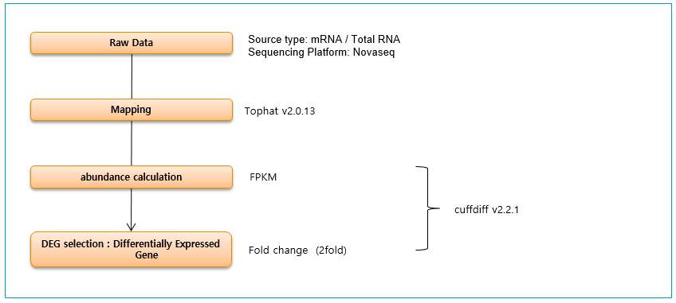

Flowchart of mRNA Processsing

### **Sequencing method**

**mRNA Sequencing using Illumina Truseq Stranded mRNA/total Library prep kit**

RNA purity was determined by assaying 1 µl of total RNA extract on a NanoDrop8000 spectrophotometer. Total RNA integrity was checked using an Agilent Technologies 2100 Bioanalyzer with an RNA Integrity Number (RIN) value.  
mrna sequencing libraries were prepared according to the manufacturer’s instructions (Illumina Truseq stranded mRNA library prep kit). MRNA was purified and fragmented from total RNA (1ug) using poly-T oligo-attached magnetic beads using two rounds of purification. Cleaved RNA Fragments primed with random hexamers were reverse transcribed into first strand cDNA using reverse transcriptase, random primers, dUTP in place of dTTP. (The incorporation of dUTP quenches the second strand during amplification, because the polymerase does not incorporate past this nucleotide.) These cDNA fragments then had the addition of a single ‘A’ base and subsequent ligation of the adapter. The products were purified and enriched with PCR to create the final strand specific cDNA library. The quality of the amplified libraries was verified by capillary electrophoresis (Bioanalyzer, Agilent).  
After QPCR using SYBR Green PCR Master Mix (Applied Biosystems), we combined libraries that index tagged in equimolar amounts in the pool. Cluster generation occurred in the flow cell on the cBot automated cluster generation system (illumina). And then the flow cell loaded on [Novaseq 6000 sequencing system (Illumina)](https://www.illumina.com/systems/sequencing-platforms/novaseq/specifications.html) , performed sequencing with 2x100bp read length.

### **DEG analysis method**

**Mapping reads on a reference genome and calculating expression between samples**

**Identification of DEGs and functional enrichment analysis**

Cuffdiff provides various output files, and using one of its outputs, “gene_exp.diff”, DEGs(Differentially Expressed Genes) were identified. To detect DEGs between sample1 as control and sample2 as case, two filtering processes were applied. First, using Cuffdiff status code, genes that only have “OK” status were extracted. Status code indicates whether each condition contains enough reads in a locus for a reliable calculation of expression level, and “OK” status means the test is successful to calculate gene expression level. For the second filtering, 2 fold change was calculated and genes belonging to the following range were selected.

Up-regulated:
$$log2[case]-log2[control] >= log2(2) =1$$
Down-regulated:
$$log2[case]-log2[control] <= log2(1/2) =-1$$

For ontology analysis, genes after 2 fold change were picked (for mouse samples, genes with 2fold&pvalue<0.05&FDR<0.05 were selected for ontology analysis) and applied to [DAVID](http://david.abcc.ncifcrf.gov/) as an input to get a comprehensive set of functional annotation. Disease, Gene ontology, pathway categories were selected, and Ease score was changed from 0.1 to 1 to include more output. Ease score is a conservative adjustment to the Fisher exact probability. It weights significance in favor of the association supported by more genes. DAVID then generated functional annotation chart which lists annotation terms and their associated genes under study.

# **Alignment Summary**

The rate at which the required readings for each sample are mapped to the reference genome.

| Sample | Reads | Mapped_Reads | Mapping_Rate |
| --- | --- | --- | --- |
| H1299-Con-1 | 50,633,558 | 43,658,649 | 86.2247 |
| H1299-Con-2 | 39,053,336 | 32,978,060 | 84.4436 |
| H1299-Con-3 | 40,680,256 | 34,485,893 | 84.7730 |
| H1299-shRB-1-m3-1 | 40,258,612 | 37,692,654 | 93.6263 |
| H1299-shRB-1-m3-2 | 45,531,056 | 42,867,552 | 94.1501 |
| H1299-shRB-1-m3-3 | 38,620,124 | 36,375,100 | 94.1869 |
| Average | 42,462,824 | 38,009,651 | 89.5700 |

# **Quality Inspection**

**Density plot** showing the distribution of FPKM(expression value) of each sample or group.

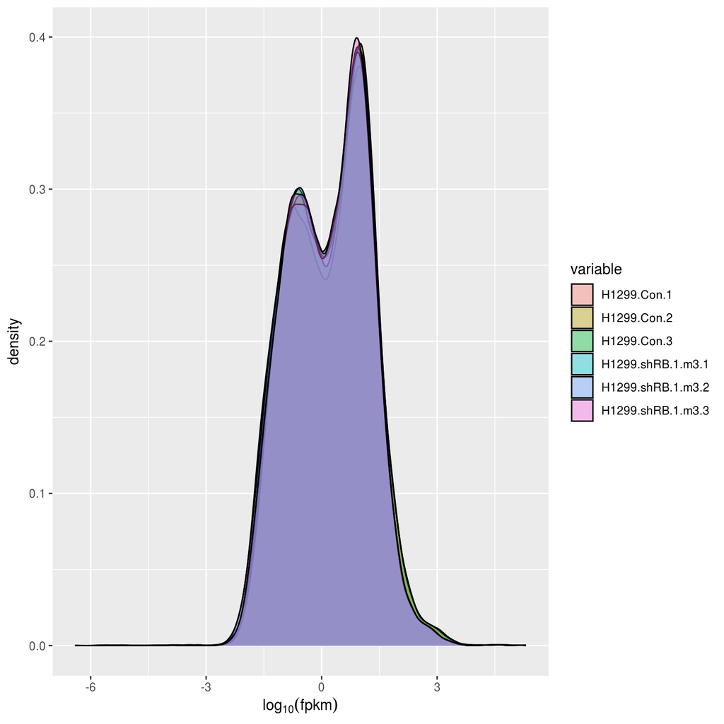

**Box plot** showing FPKM distribution of each sample or group. If there is a large difference between the median of each sample(group), it is difficult to DEG analysis.

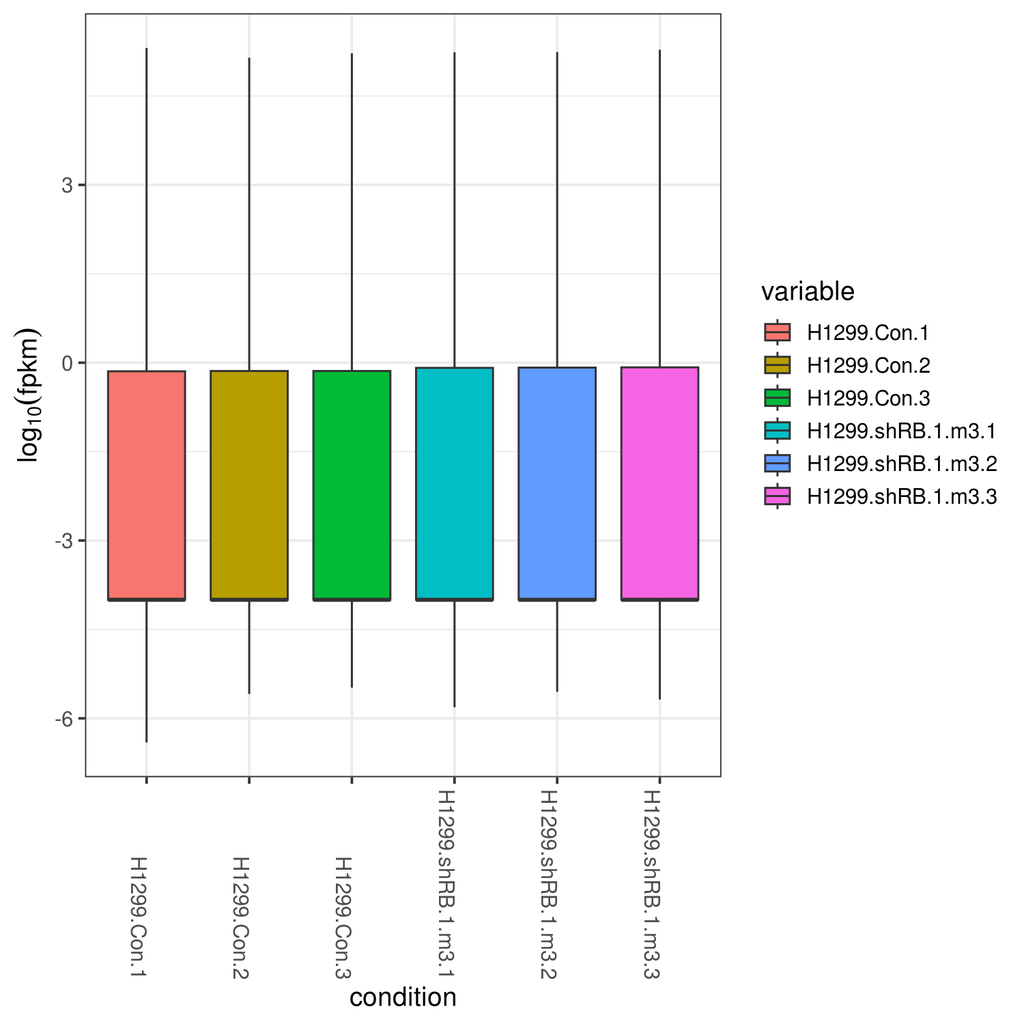

Box plot

**A correlation plot** is used to investigate the dependence between two sets of data. For example, technical or biological replicates are expected to be closely correlated, ie. similar expression values for transcripts between two samples. The result is a table containing the correlation coefficients between each variable and the others.

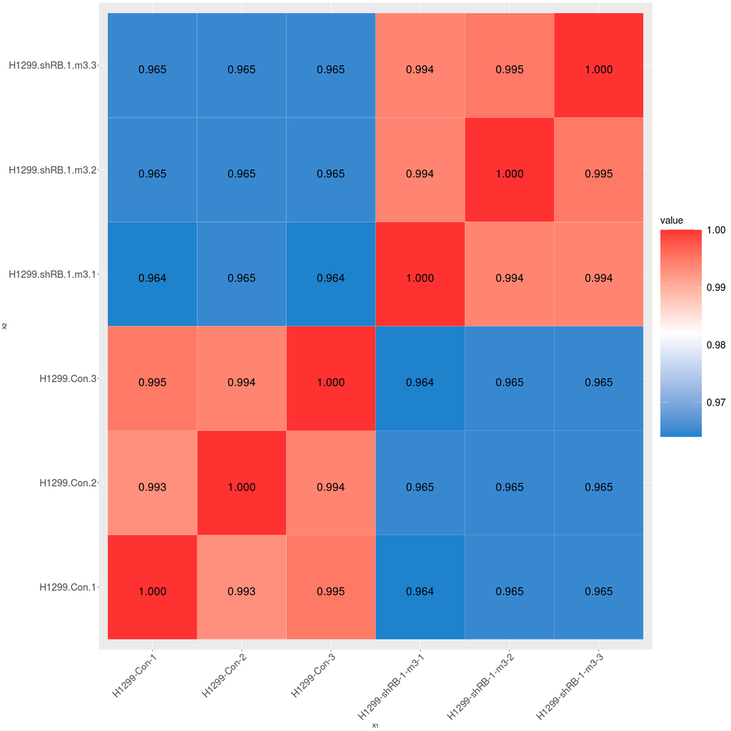

correlation_plot_pearson

# **DEG(Differentially Expressed Genes)**

#### **2fold filtering**

| Comparison | sheet | UP Regulation | Down Regulation | Total |
| --- | --- | --- | --- | --- |
| 1.H1299-Con-1,H1299-Con-2,H1299-Con-3.vs.H1299-shRB-1-m3-1,H1299-shRB-1-m3-2,H1299-shRB-1-m3-3.xlsx | 1 | 1,645 | 1,671 | 3,316 |

#### **2fold & p-value<0.05 filtering**

| Comparison | sheet | UP Regulation | Down Regulation | Total |
| --- | --- | --- | --- | --- |
| 1.H1299-Con-1,H1299-Con-2,H1299-Con-3.vs.H1299-shRB-1-m3-1,H1299-shRB-1-m3-2,H1299-shRB-1-m3-3.xlsx | 2 | 1,342 | 1,481 | 2,823 |

#### **2fold & p-value<0.05 & FDR < 0.05 filtering**

| Comparison | sheet | UP Regulation | Down Regulation | Total |
| --- | --- | --- | --- | --- |
| 1.H1299-Con-1,H1299-Con-2,H1299-Con-3.vs.H1299-shRB-1-m3-1,H1299-shRB-1-m3-2,H1299-shRB-1-m3-3.xlsx | 3 | 1,288 | 1,450 | 2,738 |

## **Scatter and Volcano plot**

Volcano Plot  
Fold-change versus significance for each gene between control and treatment: volcano plot is constructed by plotting the negative log of the p-value on the y-axis (usually base 10). This results in data points with low p-values (highly significant) appearing towards the top of the plot. The x-axis is the log of the fold change between the two conditions. The log of the fold change is used so that changes in both directions (up and down) appear equidistant from the center. (red if padj<0.05, orange of log2FC>1, green if both)

**1. H1299-Con-1,H1299-Con-2,H1299-Con-3 vs H1299-shRB-1-m3-1,H1299-shRB-1-m3-2,H1299-shRB-1-m3-3**

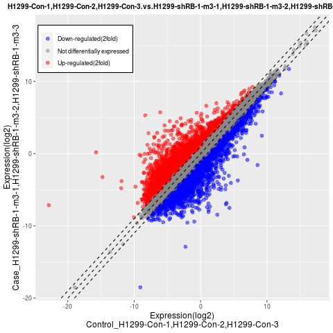

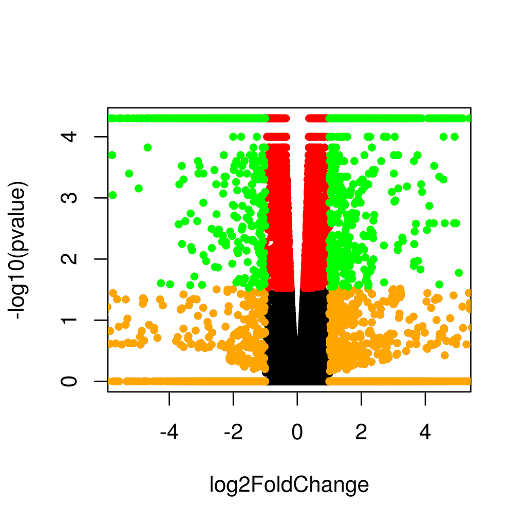

# **Ontology Results**

This is the result of an ontology analysis by selecting gene that is different than 2 fold and less than FDR 0.05. You can check the number of gene for a differential expression of more than 2fold and less than FDR 0.05, the number of gene matching the ontology database.

#### **2fold & FDR<0.05 (up)**

| Comparison | 2 fold Up & FDR<0.05 | gene in analysis |
| --- | --- | --- |
| 1.H1299-Con-1,H1299-Con-2,H1299-Con-3.vs.H1299-shRB-1-m3-1,H1299-shRB-1-m3-2,H1299-shRB-1-m3-3 | 1,288 | 979 |

#### **2fold & FDR<0.05 (down)**

| Comparison | 2 fold Down & FDR<0.05 | gene in analysis |
| --- | --- | --- |
| 1.H1299-Con-1,H1299-Con-2,H1299-Con-3.vs.H1299-shRB-1-m3-1,H1299-shRB-1-m3-2,H1299-shRB-1-m3-3 | 1,450 | 1,251 |

# **How to read result file**

### **Information of DEG result files**

#### **(In 1.DEG(Differentially Expressed Genes) directory)**

1. **test_id, gene_id, gene** : A unique identifier describing the transcipt, gene, primary transcript, or CDS being tested.
2. **locus** : Genomic coordinates for easy browsing to the genes or transcripts being tested.
3. **sample_1** : control sample or group
4. **sample_2** : case sample or group
5. **status** : Can be one of OK (test successful), NOTEST (not enough alignments for testing), LOWDATA (too complex or shallowly sequenced), HIDATA (too many fragments in locus), or FAIL, when an ill-conditioned covariance matrix or other numerical exception prevents testing.
6. **value_1** : FPKM of the gene in control sample
7. **value_2** : FPKM of the gene in case sample
8. **log2(fold_change)** : The (base 2) log of the fold change value_2/value_1
9. **absolute fold change** : absolute value of (value_2/value_1)
10. **test_stat** : The value of the test statistic used to compute significance of the observed change in FPKM
11. **p_value** : The uncorrected p-value of the test statistic
12. **q_value** : The FDR-adjusted p-value of the test statistic
13. **significant** : If q_value<0.05, significant value is marked yes
14. **column P~** : gene description

### **Information of Ontology result files**

#### **(In 3.Ontology directory)**

##### The ontology file consists of three sheets. The first sheet is a summary of the ontology results, and the second sheet is a list of the gene corresponding to each term. The third sheet is a gene list that does not match the ontology database.

1. **Category** : Annotation category provided by DAVID site (The following 6 categories are used) OMIM_DIEASE (Disease category, Only used in case of human) GOTERM_BP_ (Biological Process of Gene Ontology category) GOTERM_CC_ (Cellular Component of Gene Ontology category) GOTERM_MF_ (Molecular Function of Gene Ontology category) BIOCARTA (Pathways category) KEGG_PATHWAY (Pathways category)
2. **Term** : Functional term involved in Category
3. **EASE score** : Modified Fisher Exact P-Value. The smaller, the more significant (In general, 0.05 or 0.1 cutoff)
4. **Count(in first sheet)** : The number of genes included in the term
5. The rest columns following EASE Score column are identical to DEG file’s columns